# Lecture 3 - Linear Regression Exercises

First, load the file

```r
Advertising <- read.csv(".\Advertising.csv")
```

```
Error: '\A' is an unrecognized escape in character string starting "".\A"
```

Summarize it

```r
dim(Advertising)
```

```
[1] 200   5
```

Is there a linear relationship?

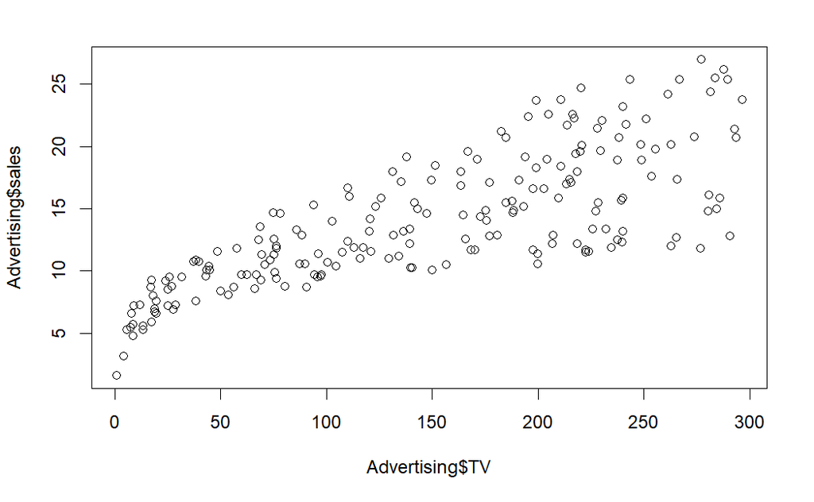

We can do a least squares fit pretty easily

By attaching the dataset, we can call the columns directly.

```r
summary(lm.fit)
```

```
Call:
lm(formula = sales ~ TV)

Residuals:
    Min      1Q  Median      3Q     Max
-8.3860 -1.9545 -0.1913  2.0671  7.2124

Coefficients:
            Estimate Std. Error t value Pr(>|t|)
(Intercept) 7.032594   0.457843   15.36   <2e-16 ***
TV          0.047537   0.002691   17.67   <2e-16 ***
---
Signif. codes:  0 ‘***’ 0.001 ‘**’ 0.01 ‘*’ 0.05 ‘.’ 0.1 ‘ ’ 1

Residual standard error: 3.259 on 198 degrees of freedom
Multiple R-squared:  0.6119,    Adjusted R-squared:  0.6099
F-statistic: 312.1 on 1 and 198 DF,  p-value: < 2.2e-16
```

We can use the function confint() to find the confidence interval for 95%

```r
confint(lm.fit)
```

```
                 2.5 %     97.5 %
(Intercept) 6.12971927 7.93546783
TV          0.04223072 0.05284256
```

## Hypothesis testing

p-value: probability of observing a value equal or larger than t

If p-value is small enough (alpha) is less than our cutoff (5% or 1%), we can reject the null hypothesis and accept that there is a relationship.

Need high t-value (absolute value) and low p-value

## R-squared and RSE

This checks how good your line fits the data. Want RSE to be low, R-squared to be high.

RSE is a measure of units of Y, so not always clear what value it *should* be.

R-squared is deviation from the mean. A high value (closer to 1), means the x-variable explains that proportion of the change in Y. A zero value means the X does not explain any change in Y.

# Multiple Regression

Multiple variables

```r
summary(lm.fit_multi)
```

```
Call:
lm(formula = sales ~ ., data = Advertising)

Residuals:
    Min      1Q  Median      3Q     Max
-8.8105 -0.9008  0.2641  1.1783  2.8336

Coefficients:
              Estimate Std. Error t value Pr(>|t|)
(Intercept)  3.0052094  0.3942082   7.623 1.06e-12 ***
X           -0.0005798  0.0020992  -0.276    0.783
TV           0.0457759  0.0013988  32.725  < 2e-16 ***
radio        0.1883832  0.0086480  21.784  < 2e-16 ***
newspaper   -0.0012433  0.0059319  -0.210    0.834
---
Signif. codes:  0 ‘***’ 0.001 ‘**’ 0.01 ‘*’ 0.05 ‘.’ 0.1 ‘ ’ 1

Residual standard error: 1.689 on 195 degrees of freedom
Multiple R-squared:  0.8973,    Adjusted R-squared:  0.8951
F-statistic: 425.7 on 4 and 195 DF,  p-value: < 2.2e-16
```

```r
summary(lm.fit_single)
```

```
Call:
lm(formula = sales ~ newspaper)

Residuals:
     Min       1Q   Median       3Q      Max
-11.2272  -3.3873  -0.8392   3.5059  12.7751

Coefficients:
            Estimate Std. Error t value Pr(>|t|)
(Intercept) 12.35141    0.62142   19.88  < 2e-16 ***
newspaper    0.05469    0.01658    3.30  0.00115 **
---
Signif. codes:  0 ‘***’ 0.001 ‘**’ 0.01 ‘*’ 0.05 ‘.’ 0.1 ‘ ’ 1

Residual standard error: 5.092 on 198 degrees of freedom
Multiple R-squared:  0.05212,   Adjusted R-squared:  0.04733
F-statistic: 10.89 on 1 and 198 DF,  p-value: 0.001148
```

Building three models by adding variables

```r
model1 <- lm(formula = sales ~ TV, data = Advertising)
summary(model1)
```

```
Call:
lm(formula = sales ~ TV, data = Advertising)

Residuals:
    Min      1Q  Median      3Q     Max
-8.3860 -1.9545 -0.1913  2.0671  7.2124

Coefficients:
            Estimate Std. Error t value Pr(>|t|)
(Intercept) 7.032594   0.457843   15.36   <2e-16 ***
TV          0.047537   0.002691   17.67   <2e-16 ***
---
Signif. codes:  0 ‘***’ 0.001 ‘**’ 0.01 ‘*’ 0.05 ‘.’ 0.1 ‘ ’ 1

Residual standard error: 3.259 on 198 degrees of freedom
Multiple R-squared:  0.6119,    Adjusted R-squared:  0.6099
F-statistic: 312.1 on 1 and 198 DF,  p-value: < 2.2e-16
```

```r
model2 <- lm(formula = sales ~ TV + radio, data = Advertising)
summary(model2)
```

```
Call:
lm(formula = sales ~ TV + radio, data = Advertising)

Residuals:
    Min      1Q  Median      3Q     Max
-8.7977 -0.8752  0.2422  1.1708  2.8328

Coefficients:
            Estimate Std. Error t value Pr(>|t|)
(Intercept)  2.92110    0.29449   9.919   <2e-16 ***
TV           0.04575    0.00139  32.909   <2e-16 ***
radio        0.18799    0.00804  23.382   <2e-16 ***
---
Signif. codes:  0 ‘***’ 0.001 ‘**’ 0.01 ‘*’ 0.05 ‘.’ 0.1 ‘ ’ 1

Residual standard error: 1.681 on 197 degrees of freedom
Multiple R-squared:  0.8972,    Adjusted R-squared:  0.8962
F-statistic: 859.6 on 2 and 197 DF,  p-value: < 2.2e-16
```

```r
model3 <- lm(formula = sales ~ ., data = Advertising)
summary(model3)
```

```
Call:
lm(formula = sales ~ ., data = Advertising)

Residuals:
    Min      1Q  Median      3Q     Max
-8.8105 -0.9008  0.2641  1.1783  2.8336

Coefficients:
              Estimate Std. Error t value Pr(>|t|)
(Intercept)  3.0052094  0.3942082   7.623 1.06e-12 ***
X           -0.0005798  0.0020992  -0.276    0.783
TV           0.0457759  0.0013988  32.725  < 2e-16 ***
radio        0.1883832  0.0086480  21.784  < 2e-16 ***
newspaper   -0.0012433  0.0059319  -0.210    0.834
---
Signif. codes:  0 ‘***’ 0.001 ‘**’ 0.01 ‘*’ 0.05 ‘.’ 0.1 ‘ ’ 1

Residual standard error: 1.689 on 195 degrees of freedom
Multiple R-squared:  0.8973,    Adjusted R-squared:  0.8951
F-statistic: 425.7 on 4 and 195 DF,  p-value: < 2.2e-16
```

# Extensions of the Linear Model

## Variables Interact

Maybe two variables interact to increase the effect (example: two medications taken together, TV and radio ads at the same time)

We can see that interaction

```r
lm.fit1 <- lm(formula = sales ~TV*radio, data = Advertising) # we use * between the variables so R considers them independently as well as together
summary(lm.fit1)
```

```
Call:
lm(formula = sales ~ TV * radio, data = Advertising)

Residuals:
    Min      1Q  Median      3Q     Max
-6.3366 -0.4028  0.1831  0.5948  1.5246

Coefficients:
             Estimate Std. Error t value Pr(>|t|)
(Intercept) 6.750e+00  2.479e-01  27.233   <2e-16 ***
TV          1.910e-02  1.504e-03  12.699   <2e-16 ***
radio       2.886e-02  8.905e-03   3.241   0.0014 **
TV:radio    1.086e-03  5.242e-05  20.727   <2e-16 ***
---
Signif. codes:  0 ‘***’ 0.001 ‘**’ 0.01 ‘*’ 0.05 ‘.’ 0.1 ‘ ’ 1

Residual standard error: 0.9435 on 196 degrees of freedom
Multiple R-squared:  0.9678,    Adjusted R-squared:  0.9673
F-statistic:  1963 on 3 and 196 DF,  p-value: < 2.2e-16
```